# Small Group Collaboration - Session 4

October 15, 2020

## Data

We’ll investigate the `credit` dataset from the textbook, which has 400 observations on customer’s financial information.

```
## Rows: 400
## Columns: 10
## $ ID            <int> 1, 2, 3, 4, 5, 6, 7, 8, 9, 10, 11, 12, 13, 14, 15, 16, …
## $ debt          <int> 333, 903, 580, 964, 331, 1151, 203, 872, 279, 1350, 140…
## $ credit_limit  <int> 3606, 6645, 7075, 9504, 4897, 8047, 3388, 7114, 3300, 6…
## $ income        <dbl> 14.891, 106.025, 104.593, 148.924, 55.882, 80.180, 20.9…
## $ credit_rating <int> 283, 483, 514, 681, 357, 569, 259, 512, 266, 491, 589, …
## $ age           <int> 34, 82, 71, 36, 68, 77, 37, 87, 66, 41, 30, 64, 57, 49,…
## $ student       <fct> No, Yes, No, No, No, No, No, No, No, Yes, No, No, No, N…
## $ cards         <int> 2, 3, 4, 3, 2, 4, 2, 2, 5, 3, 4, 3, 1, 1, 2, 3, 3, 3, 1…
## $ married       <fct> Yes, Yes, No, No, Yes, No, No, No, No, Yes, Yes, No, Ye…
## $ ethnicity     <fct> Caucasian, Asian, Asian, Asian, Caucasian, Caucasian, A…
```

## Exploratory Data Analysis

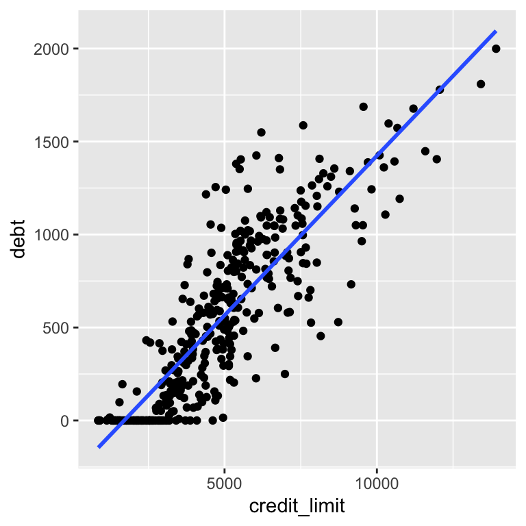

What other variables do believe may impact this relationship?

How would you explore that relationship?

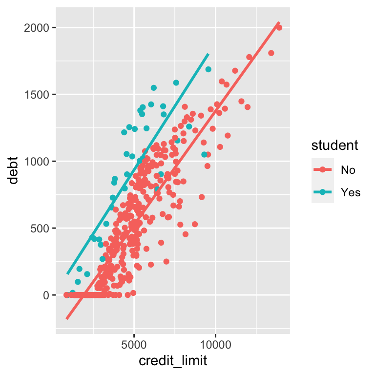

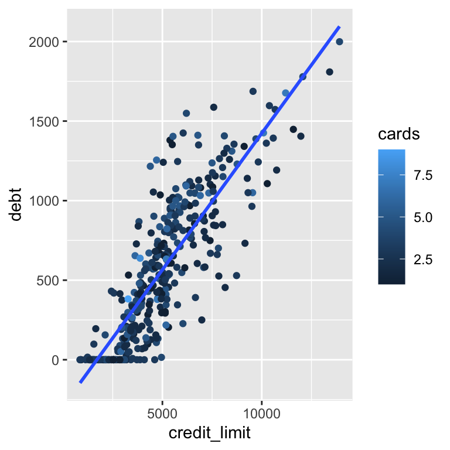

What do you see in these visualizations?

## Modeling Debt with Credit Limit

```r
debt_model1 <- lm(debt ~ credit_limit, data = credit)
```

```
## # A tibble: 2 x 7
##   term         estimate std_error statistic p_value lower_ci upper_ci
##   <chr>           <dbl>     <dbl>     <dbl>   <dbl>    <dbl>    <dbl>
## 1 intercept    -293.       26.7       -11.0       0 -345.    -240.
## 2 credit_limit    0.172     0.005      33.9       0    0.162    0.182
```

How would you interpret the relationship between credit card debt and credit card limit?

Who does this regression apply to?

## Adding in Student Variable

```r
debt_model2 <- lm(debt ~ credit_limit + student, data = credit)
```

What type of model was fit? Is that appropriate given what you saw in the visualization?

## Interpreting

```r
debt_model2 <- lm(debt ~ credit_limit + student, data = credit)
```

```
## # A tibble: 3 x 7
##   term         estimate std_error statistic p_value lower_ci upper_ci
##   <chr>           <dbl>     <dbl>     <dbl>   <dbl>    <dbl>    <dbl>
## 1 intercept    -335.       23.1       -14.5       0 -380.     -289.
## 2 credit_limit    0.172     0.004      39.7       0    0.163     0.18
## 3 studentYes    404.       33.3        12.2       0  339.      470.
```

What is the estimated regression line for students?

What does this model assume about the relationship between debt and credit limit?

## Model Fit

[output not shown]

How much additional variability in debt can we explain when adding in whether the individual was a student?

## Alternative Model – Number of Cards

```r
debt_model3 <- lm(debt ~ credit_limit + cards, data = credit)

get_regression_table(debt_model3)
```

```
## # A tibble: 3 x 7
##   term         estimate std_error statistic p_value lower_ci upper_ci
##   <chr>           <dbl>     <dbl>     <dbl>   <dbl>    <dbl>    <dbl>
## 1 intercept    -369.       36.2      -10.2    0     -440.    -298.
## 2 credit_limit    0.171     0.005     34.2    0        0.162    0.181
## 3 cards          26.0       8.44       3.08   0.002    9.44    42.6
```

What type of explanatory variable is `cards`?

How do we interpret the slope on `credit_limit`?

How do we interpret the slope on `cards`?

## Model Fit

[output not shown]

Which model does a better job of explaining debt?

## Issues with Credit Limits?

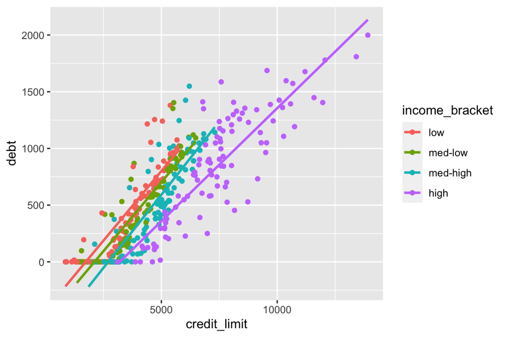

Which group(s) appear to have similar relationships between credit limit and debt?

## Modeling the Wealthy

How would we create a variable that indicated whether someone was wealthy or not?

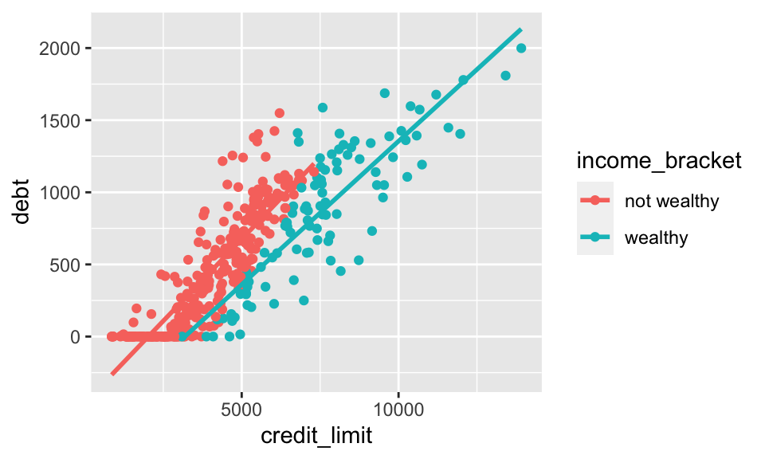

What type of regression should we use to model this relationship?